# Creative Assignment 1

Maggie Weese

9/9/2020

# Loading Library and Datasets

Below is my code for loading my libraries and variables. I looked at data from the 2010 census at the tract level. The variables I selected include:

1. Percentage of rental households
2. Majority race in census tract
3. Majority sex
4. Median age
5. Average household size
6. Percentage of “Nonfamily” households

```r
library(ggplot2)
library(tidyverse)
library(tidycensus)
library(RColorBrewer)
library(wesanderson)
```

```r
#The code for variables rent, majority race, and age are used from Carole's demo data on GitHub

vara <- c(tot_hh = "H001001",
         tot_rent_hh = "H004004",
         avg_hh_size = "H012001",
         tot_pop = "P003001",
         nh_white_pop = "P005003",
         nh_black_pop = "P005004",
         nh_asian_pop = "P005006",
         hispanic_pop = "P005010",
         total_hh = "PCT016001",
         total_nonfam_hh = "PCT016021",
         total_sex = "P012001",
         total_fem = "P012002",
         total_male = "P012026",
         med_age = "P013001")

Bmore_tracts <- get_decennial(geography = "tract", variables = vara,
                           state = "MD", county = "Baltimore City",
                           output = "wide") %>%
  mutate(pct_rental = tot_rent_hh / tot_hh,
         pct_nonfam_hh = total_nonfam_hh / total_hh,
         majority_sex = case_when(
           total_fem / total_sex > 0.5 ~ "fem",
           total_male / total_sex > 0.5 ~ "male"),
         majority_race_eth = case_when(
           nh_white_pop / tot_pop > 0.5 ~ "nh_white",
           nh_black_pop / tot_pop > 0.5 ~ "nh_black",
           nh_asian_pop / tot_pop > 0.5 ~ "nh_asian",
           hispanic_pop / tot_pop > 0.5 ~ "hispanic",
           (nh_white_pop + nh_black_pop + nh_asian_pop + hispanic_pop) /
             tot_pop < 0.5 ~ "other",
           TRUE ~ "None")) %>%
  filter(tot_pop > 0, tot_hh > 0) %>%
  select(GEOID, majority_race_eth,
         pct_rental, avg_hh_size, tot_pop, med_age, majority_sex, pct_nonfam_hh)
```

```
## Using Census Summary File 1
```

## Creation of Graphs

### Graph 1 - Scatter Plot - Iteration 1

In this initial scatter plot I looked at average household size in each Baltimore census tracts compared to the percentage of rental households in the tract. I added color to designate the majority gender in each tract. While a good initial try, this graph did not give me a very clear picture of any relationship and I think the use of color to highlight sex may take away from/abstract the relationship.

The basis of this code came from Carole’s example in Github.

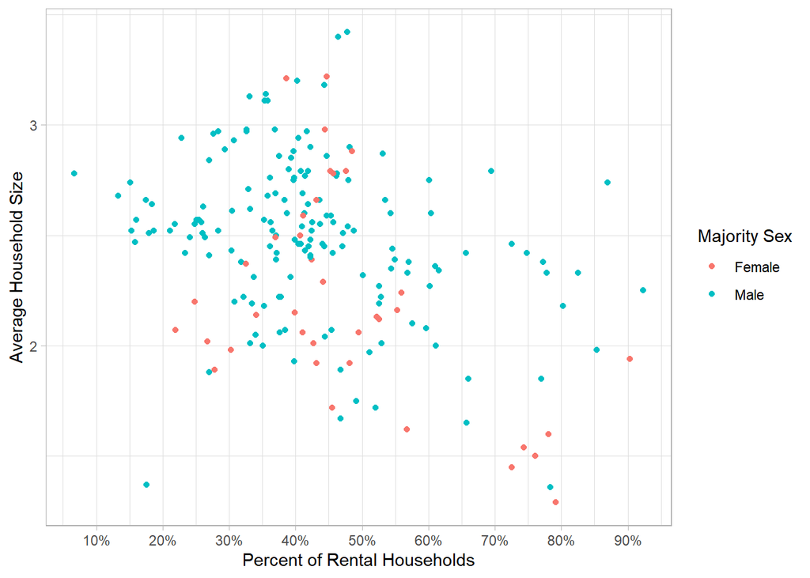

```r
ggplot(Bmore_tracts,
       aes(x = pct_rental,
           y = avg_hh_size,
           color = majority_sex)) +
  geom_point() +
  scale_x_continuous(name = "Percent of Rental Households",
                     breaks = seq(0, 1, by = 0.1),
                     labels = paste(seq(0, 100, by = 10), "%", sep = "")) +
    scale_y_continuous(name = "Average Household Size", breaks = seq(0, 5, by = 1)) +
  scale_color_discrete(name = "Majority Sex",
                       labels = c("Female", "Male")) +
  theme_light()
```

### Graph 2 - Scatter Plot - Iteration 2

As we discussed in class, often less is more in data visualization so I removed the color-coding and instead added a trend line. While still not great, I think this graph does a better job highlighting the relationship between the variables.

The basis of this code came from Carole’s example in Github.

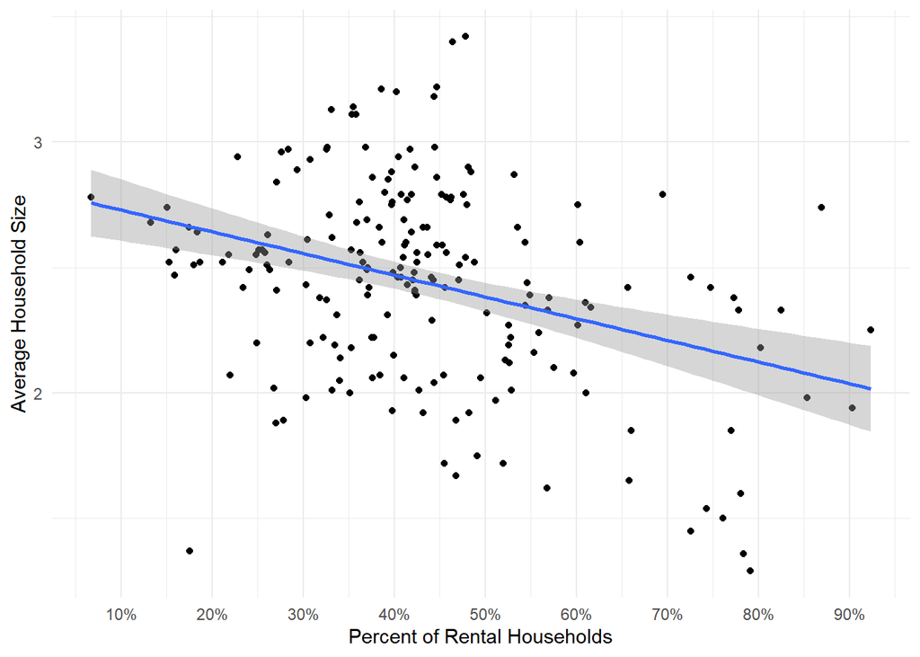

```r
ggplot(Bmore_tracts,
       aes(x = pct_rental,
           y = avg_hh_size)) +
  geom_point() +
  stat_smooth(method = "lm") +
  scale_x_continuous(name = "Percent of Rental Households",
                     breaks = seq(0, 1, by = 0.1),
                     labels = paste(seq(0, 100, by = 10), "%", sep = "")) +
  scale_y_continuous(name = "Average Household Size", breaks = seq(0, 5, by = 1)) +
  theme_minimal()
```

### Graph 3 - Scatter Plot, Use of Size

In this plot, I played around with the use of dot size to represent a variable and learned from R’s error code that it is not advised to use size for a categorical set of data.

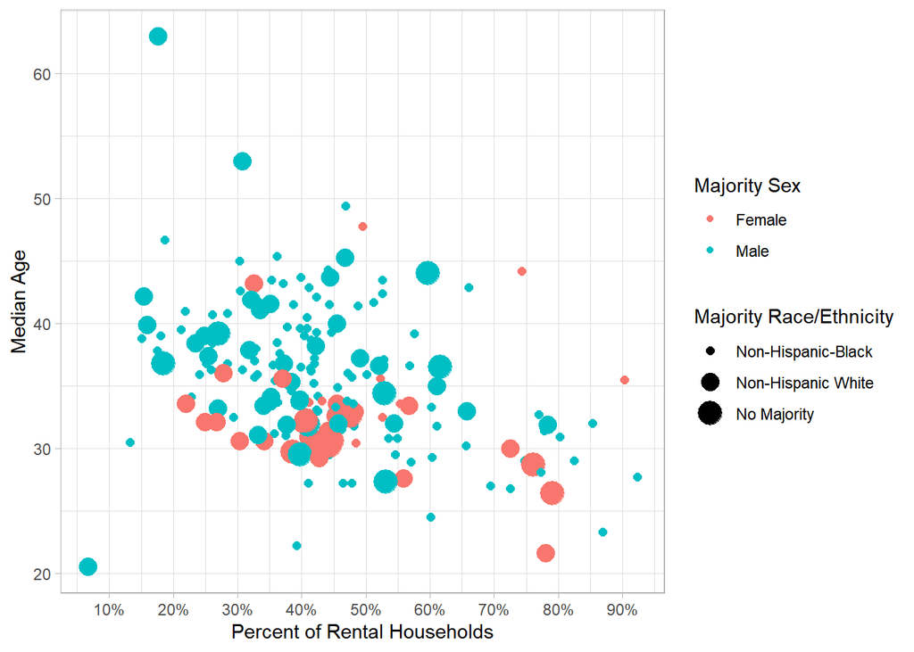

```r
ggplot(Bmore_tracts,
       aes(x = pct_rental,
           y = med_age,
           color = majority_sex,
           size = majority_race_eth)) +
  geom_point() +
  scale_x_continuous(name = "Percent of Rental Households",
                     breaks = seq(0, 1, by = 0.1),
                     labels = paste(seq(0, 100, by = 10), "%", sep = "")) +
  scale_y_continuous(name = "Median Age",
                     breaks = seq(10, 80, by = 10)) +
  scale_color_discrete(name = "Majority Sex",
                       labels = c("Female", "Male")) +
  scale_size_discrete(name = "Majority Race/Ethnicity",
          labels = c("Non-Hispanic-Black",
                                  "Non-Hispanic White",
                                  "No Majority")) +
  theme_light()
```

### Graph 4 - Violin Plots and Exploring Fill

In this plot I used violin plots to understand the relationship between the percentage of rental households and majority race. While fun to make, I did not think this graph told too much except that the percentage of rental households is relatively evenly distributed actross the three race/ethnicities.

The basis of this code came from Carole’s example in Github with modifications.

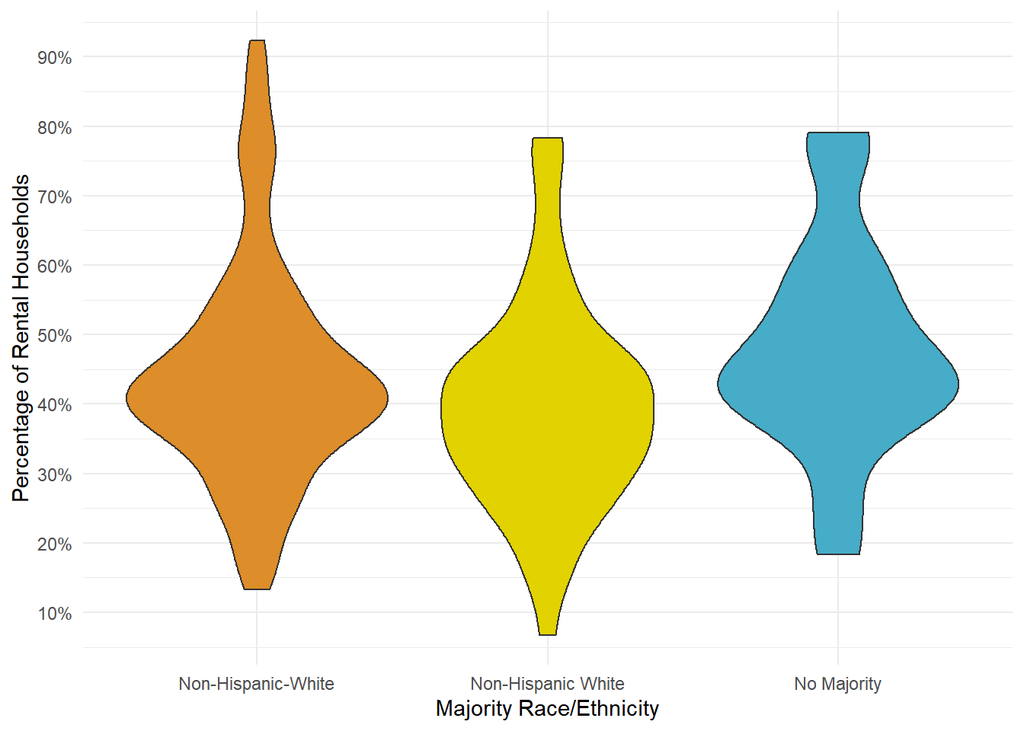

```r
ggplot(Bmore_tracts,
       aes(x = majority_race_eth,
           y = pct_rental,
           fill= majority_race_eth)) +
  geom_violin() +
  scale_fill_manual(values = wes_palette("FantasticFox1", n = 3)) +
  scale_x_discrete(name = "Majority Race/Ethnicity",
                            labels = c("Non-Hispanic-White",
                                  "Non-Hispanic White",
                                  "No Majority")) +
  scale_y_continuous(name = "Percentage of Rental Households",
                    breaks = seq(0,1 , by = 0.1),
                     labels = paste(seq(0, 100, by = 10), "%", sep = "")) +
    theme_minimal() +
  theme(legend.position = "none")
```

### Graph 5 - Violin Plots

I then went on to see the different ways I could represent the relationship between categorical and continuous data, focusing on the relationship between majority sex and percentage of rental households.

The basis of this code came from Carole’s example in Github with modifications.

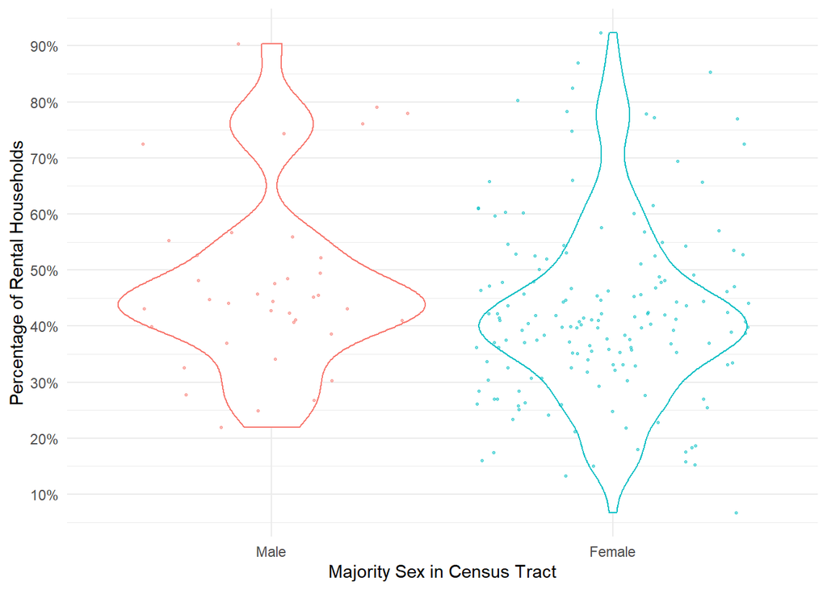

```r
ggplot(Bmore_tracts,
       aes(x = majority_sex,
           y = pct_rental,
           color = majority_sex)) +
  geom_violin() +
  geom_point(position = "jitter",
             alpha = 0.5,
             size = 0.5) +
  scale_fill_manual(values = "Blue") +
  scale_x_discrete(name = "Majority Sex in Census Tract",
                   labels = c("Male",
                                  "Female")) +
  scale_y_continuous(name = "Percentage of Rental Households",
                     breaks = seq(0,1 , by = 0.1),
                     labels = paste(seq(0, 100, by = 10), "%", sep = "")) +
    theme_minimal() +
  theme(legend.position = "none")
```

### Graph 6 - Boxplots

My second interaction of representing the relationship between majority sex and percentage of rental households was through boxplots. I found these graphs to be much clearer to read and understand.

The basis of this code came from Carole’s example in Github with modifications.

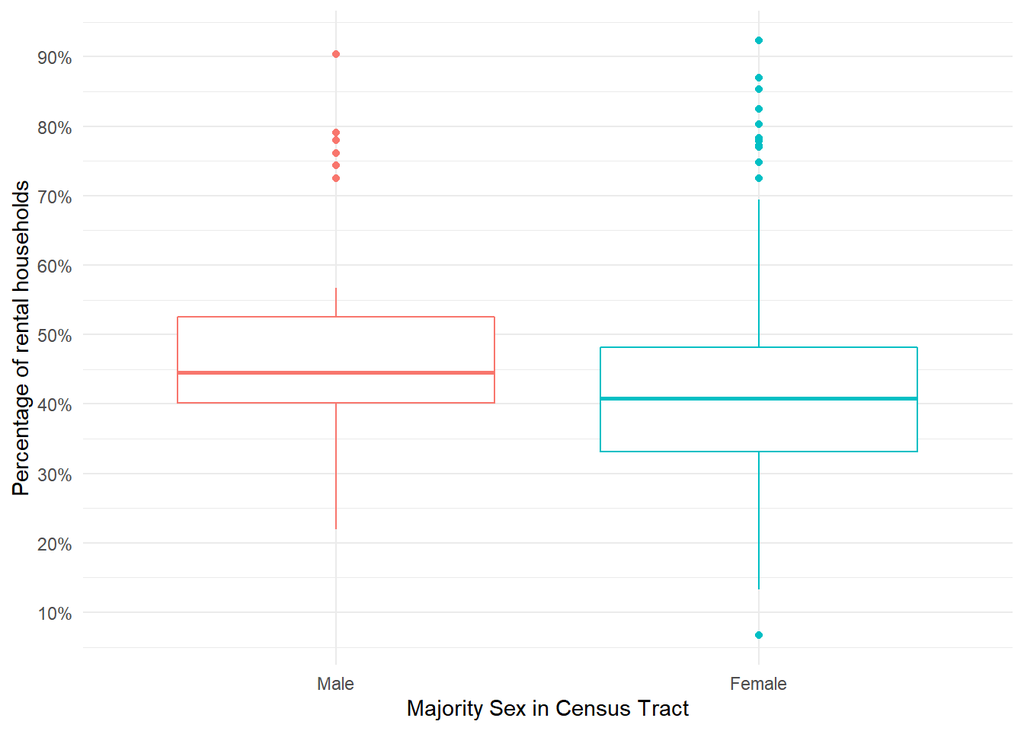

```r
ggplot(Bmore_tracts,
       aes(x = majority_sex,
           y = pct_rental,
           color = majority_sex)) +
  geom_boxplot() +
  scale_x_discrete(name = "Majority Sex in Census Tract",
                       labels = c("Male",
                                  "Female")) +
  scale_y_continuous(name = "Percentage of rental households",
                     breaks = seq(0,1 , by = 0.1),
                     labels = paste(seq(0, 100, by = 10), "%", sep = "")) +
    theme_minimal() +
  theme(legend.position = "none")
```

### Graph 7 - Categorical Data through Bar Graphs - Iteration 1

In this graph I explored representing two pieces of categorical data - majority race/ethnicity and majority sex. I made two iterations of this graph, one that stacked the data and one that showed the data side by side. While I thought I would be partial to showing them side-by-side, I actually like the stacked representation better and think it is more clear.

The basis of this code came from Carole’s example in Github.

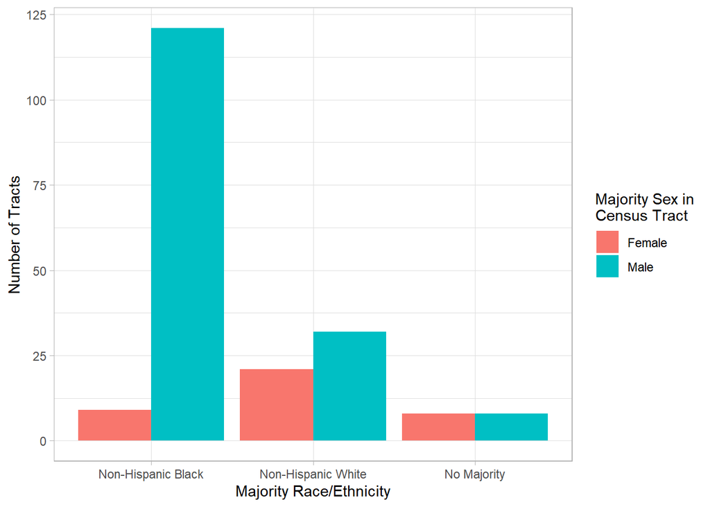

```r
ggplot(Bmore_tracts,
       aes(x = majority_race_eth, fill = majority_sex)) +
  geom_bar(position = "dodge") +
  scale_y_continuous(name = "Number of Tracts") +
  scale_x_discrete(name = "Majority Race/Ethnicity",
                       labels = c("Non-Hispanic Black", "Non-Hispanic White", "No Majority")) +
    scale_fill_discrete(name = "Majority Sex in\nCensus Tract",
                       labels = c("Female", "Male"))+
  theme_light()
```

### Graph 8 - Categorical Data through Bar Graphs - Iteration 2

The basis of this code came from Carole’s example in Github.

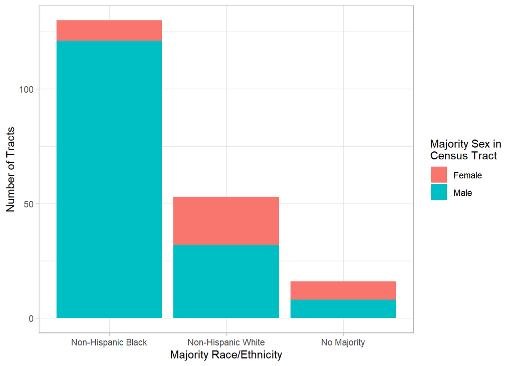

```r
ggplot(Bmore_tracts,
       aes(x = majority_race_eth, fill = majority_sex)) +
  geom_bar() +
  scale_y_continuous(name = "Number of Tracts") +
  scale_x_discrete(name = "Majority Race/Ethnicity",
                       labels = c("Non-Hispanic Black", "Non-Hispanic White", "No Majority")) +
    scale_fill_discrete(name = "Majority Sex in\nCensus Tract",
                       labels = c("Female", "Male"))+
  theme_light()
```

### Graph 9 Scatter Plots with three Variables - Iteration 1

The basis of this code came from Carole’s example in Github.

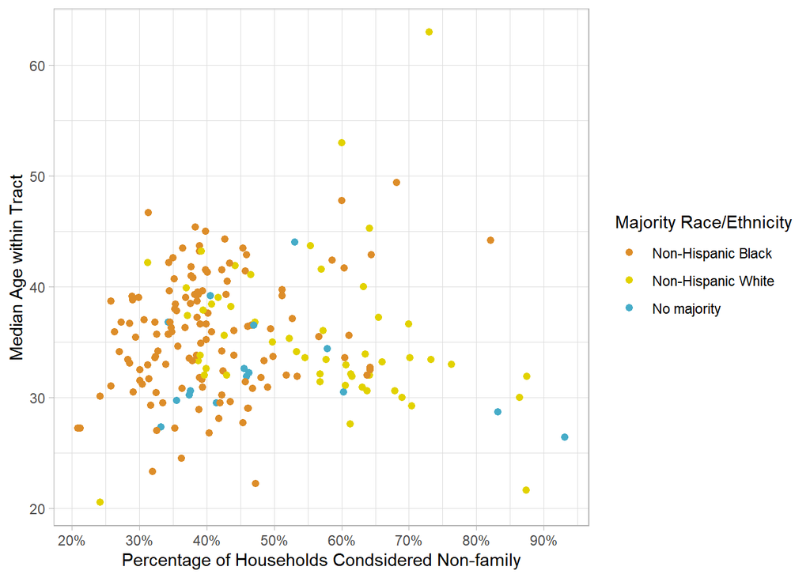

```r
ggplot(Bmore_tracts,
       aes(x = pct_nonfam_hh,
           y = med_age,
           color = majority_race_eth)) +
  geom_point(size=1.8) +
  scale_x_continuous(name = "Percentage of Households Condsidered Non-family",
                     breaks = seq(0, 1, by = 0.1),
                     labels = paste(seq(0, 100, by = 10), "%", sep = "")) +
  scale_y_continuous(name = "Median Age within Tract",
                     breaks = seq(10, 80, by = 10)) +
   scale_color_manual(values = wes_palette("FantasticFox1", n = 3), name = "Majority Race/Ethnicity",
                       labels = c("Non-Hispanic Black",
                                  "Non-Hispanic White",
                                  "No majority")) +
  theme_light()
```

### Graph 10 Scatter Plots with three Variables - Iteration 2

The basis of this code came from Carole’s example in Github.

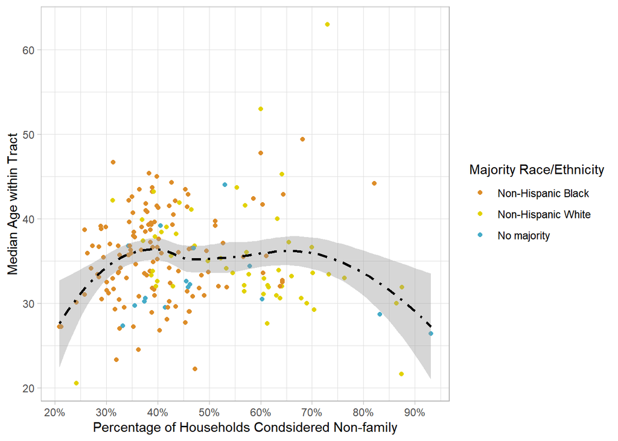

```r
ggplot(Bmore_tracts,
       aes(x = pct_nonfam_hh,
           y = med_age,
           color = majority_race_eth)) +
  geom_point(size=1.5) +
  stat_smooth(color = "black", linetype = 4, size = 1) +
  scale_x_continuous(name = "Percentage of Households Condsidered Non-family",
                     breaks = seq(0, 1, by = 0.1),
                     labels = paste(seq(0, 100, by = 10), "%", sep = "")) +
  scale_y_continuous(name = "Median Age within Tract",
                     breaks = seq(10, 80, by = 10)) +
   scale_color_manual(values = wes_palette("FantasticFox1", n = 3), name = "Majority Race/Ethnicity",
                       labels = c("Non-Hispanic Black",
                                  "Non-Hispanic White",
                                  "No majority")) +
   theme_light()
```

### Graph 11 - Bar Graph of Continuous Data

This graph shows the distribution in median age across all tracts. I am not sure why but I find this graph really interesting although not the most visually appealing of the bunch.

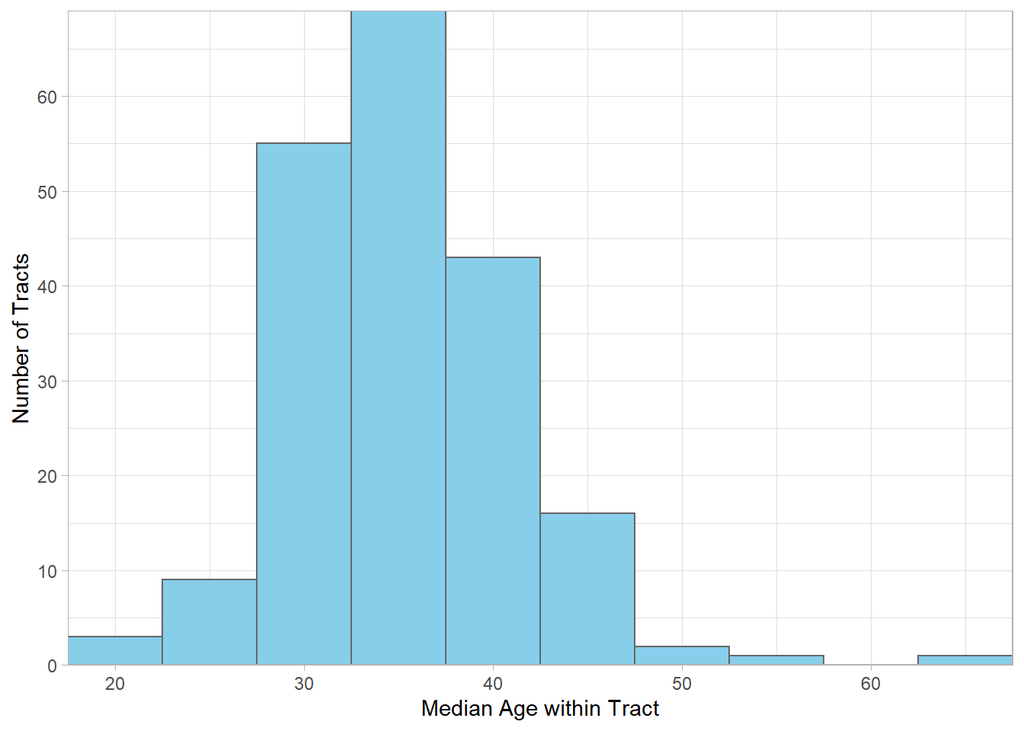

```r
ggplot(Bmore_tracts, aes(x = med_age, n = 3)) +
  scale_x_continuous(name = "Median Age within Tract",
                     expand = c(0,0)) +
  scale_y_continuous(name = "Number of Tracts", expand = c(0,0), breaks = seq(0, 100, by = 10)) +
  geom_histogram(binwidth = 5, color = "gray40", fill = "skyblue") +
  theme_light()
```

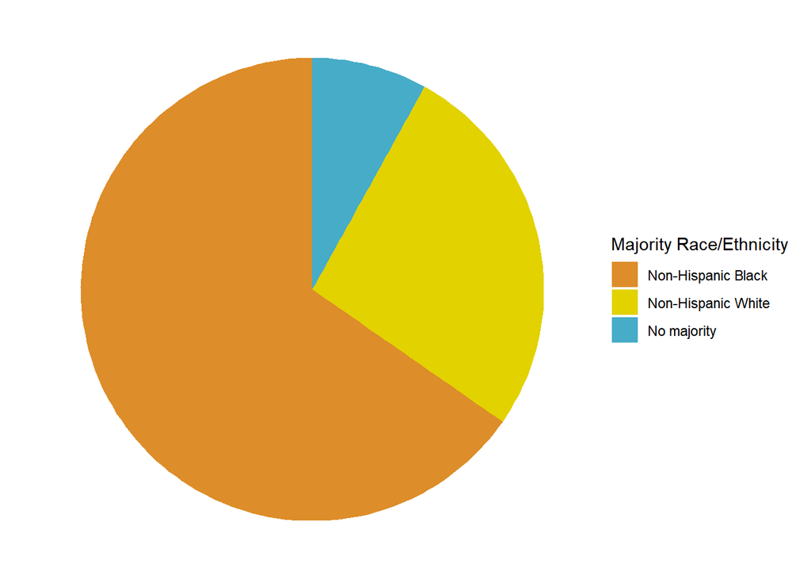

```r
pie_chart <- ggplot(Bmore_tracts, aes(x = 1, fill = majority_race_eth)) +
  geom_bar(position = "fill") +
  coord_polar(theta = "y") +
  scale_y_continuous(name = "Number of tracts") +
    scale_fill_manual(values = wes_palette("FantasticFox1", n = 3),
                      name = "Majority Race/Ethnicity",
                       labels = c("Non-Hispanic Black",
                                  "Non-Hispanic White",
                                  "No majority")) +


  theme_void()

pie_chart
```

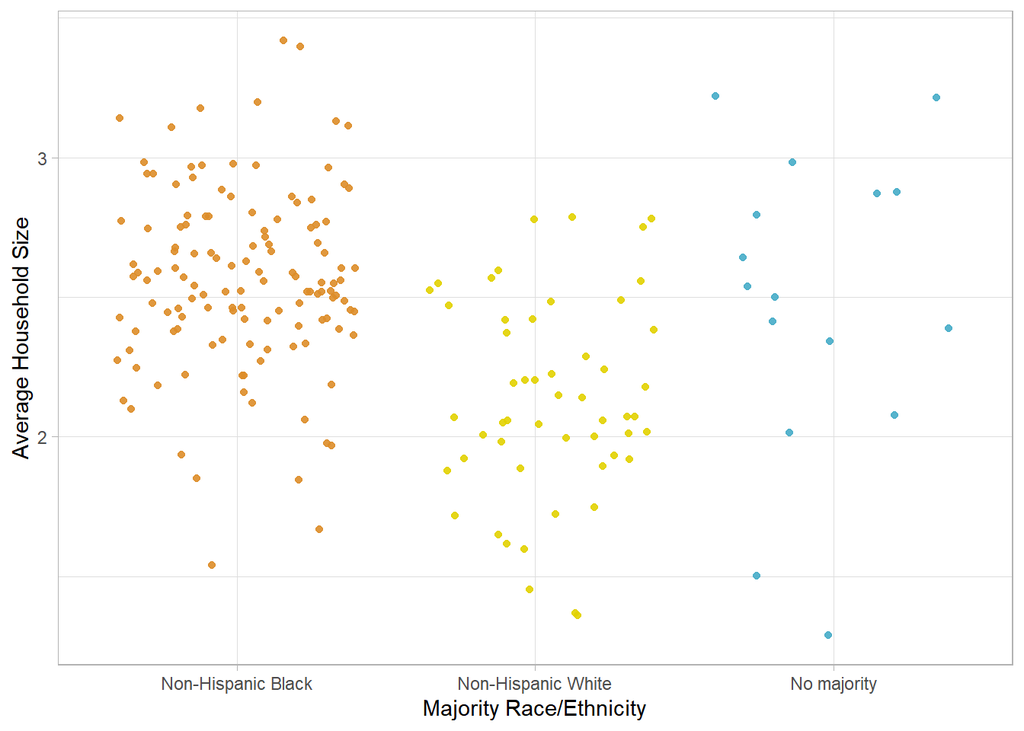

```r
ggplot(Bmore_tracts,
       aes(x = majority_race_eth,
           y = avg_hh_size,
           color = majority_race_eth)) +
 scale_color_manual(values = wes_palette("FantasticFox1", n = 3)) +
 geom_point(position = "jitter",
             size = 1.5,
             alpha = 0.9) +
  scale_x_discrete(name = "Majority Race/Ethnicity",
                       labels = c("Non-Hispanic Black",
                                  "Non-Hispanic White",
                                  "No majority")) +
  scale_y_continuous(name = "Average Household Size",
                     breaks = seq(1, 10, by = 1)) +
  theme_light() +
  theme(legend.position = "none")
```

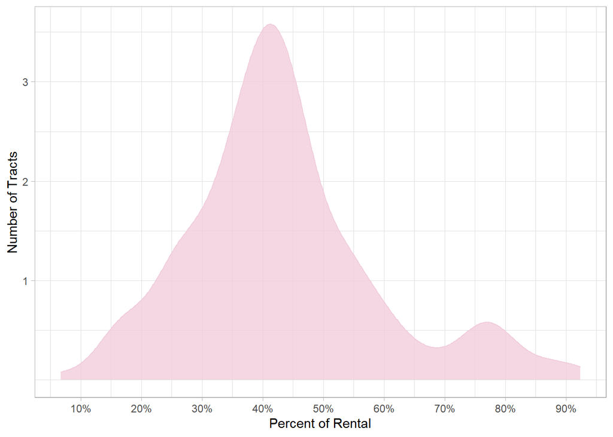

```r
ggplot(Bmore_tracts, aes(x = pct_rental)) +
  geom_density(fill="#f1cddc", color="#f1cddc", alpha=0.8) +
  scale_x_continuous(name = "Percent of Rental",
                     breaks = seq(0, 1, by = 0.1),
                     labels = paste(seq(0, 100, by = 10), "%", sep = "")) +
   scale_y_continuous(name = "Number of Tracts",
                     breaks = seq(1, 10, by = 1)) +
  theme_light()
```